# Análisis de un experimento en franjas (Strip-Plot)

Influencia del nitrógeno y riego en el rendimiento de maíz

Dr. Byron González (http://byrong.cc)”

# Introducción

Este documento detalla el análisis de un experimento agrícola bifactorial con arreglo en franjas (o *strip-plot*). El objetivo es evaluar el efecto de diferentes dosis de **Nitrógeno** (factor en franjas horizontales) y niveles de **Riego** (factor en franjas verticales) sobre el **Rendimiento** de un cultivo de maíz (`Rend`). El diseño también considera un efecto de **Bloque** para controlar la variabilidad espacial.

# 1. Carga de Bibliotecas

Primero, se colocan en memoria todas las bibliotecas necesarias para el análisis. El siguiente código verifica si cada paquete está instalado; de no ser así, lo instalará antes de cargarlo.

```r
# Lista de paquetes requeridos
packages <- c("readxl", "data.table", "agricolae", "emmeans",
              "ggplot2", "tidyverse", "AgroR")

# Función para instalar y cargar paquetes
install_and_load <- function(pkg){
  if(!require(pkg, character.only = TRUE)){
    install.packages(pkg, dependencies = TRUE)
    library(pkg, character.only = TRUE)
  }
}

# Aplicar la función a todos los paquetes
sapply(packages, install_and_load)
```

# 2. Importación de datos

Los datos se importan directamente desde una URL. Se emplea `data.table::fread` por su eficiencia y su capacidad para manejar delimitadores y decimales específicos.

```r
franjas <- fread("https://archive.org/download/byrong_Maiz/Maiz.txt", header = TRUE, sep = "\t", dec = ",")

# Se muestran las primeras filas para verificar la carga correcta
head(franjas)
```

```
##    Bloque Nitrog  Riego  Rend
##     <int>  <int> <char> <int>
## 1:      1      0   Bajo    55
## 2:      1    100   Bajo    69
## 3:      1     50   Bajo    62
## 4:      1      0   Alto    71
## 5:      1    100   Alto    78
## 6:      1     50   Alto    77
```

# 3. Preparación de los datos

Para que el modelo de análisis de varianza (ANDEVA) interprete correctamente las variables categóricas, se convierten las columnas `Nitrog`, `Riego` y `Bloque` a factores. La variable de respuesta `Rend` ya es numérica.

```r
# Convertir variables a factores
nitr<- factor(franjas$Nitrog)
riego<- factor(franjas$Riego)
bloque<-factor(franjas$Bloque)

# Variable de respuesta numérica
resp<-as.vector(franjas$Rend)
resp1<-as.numeric(resp)

# Se verifica la estructura de los datos
str(franjas)
```

```
## Classes 'data.table' and 'data.frame':   24 obs. of  4 variables:
##  $ Bloque: int  1 1 1 1 1 1 2 2 2 2 ...
##  $ Nitrog: int  0 100 50 0 100 50 100 0 50 100 ...
##  $ Riego : chr  "Bajo" "Bajo" "Bajo" "Alto" ...
##  $ Rend  : int  55 69 62 71 78 77 81 77 79 77 ...
##  - attr(*, ".internal.selfref")=<externalptr>
```

# 4. Análisis exploratorio: Gráfico de interacción

Un gráfico de interacción es fundamental para visualizar cómo el efecto de un factor (Nitrógeno) puede cambiar según el nivel de otro factor (Riego). Si las líneas no son paralelas, sugiere una posible interacción entre los factores.

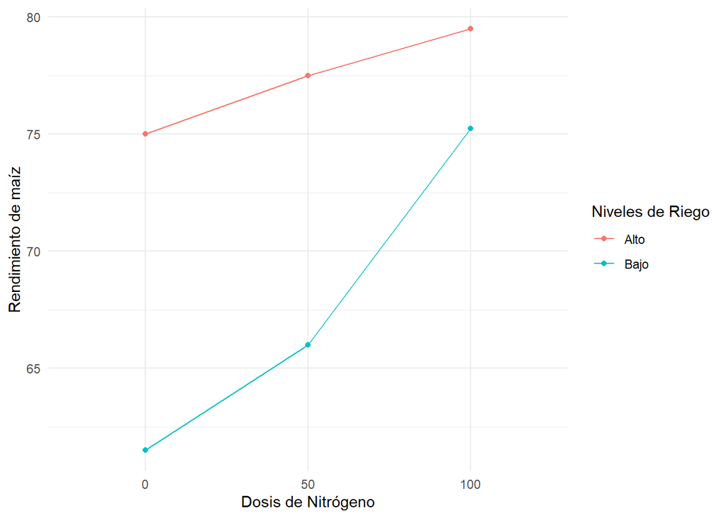

```r
franjas %>%
  ggplot() +
  aes(x = nitr, color = riego, group = riego, y = resp1) +
  stat_summary(fun = mean, geom = "point") +
  stat_summary(fun = mean, geom = "line") +
  xlab("Dosis de Nitrógeno") + ylab("Rendimiento de maíz")+
  labs(colour = "Niveles de Riego")+
  theme_minimal()
```

El gráfico muestra que las líneas no son paralelas. Esto indica una probable interacción entre el Nitrógeno y el Riego. El rendimiento parece aumentar con la dosis de nitrógeno, pero la magnitud de este aumento depende del nivel de riego aplicado.

# 5. Análisis de Varianza (ANDEVA)

## 5.1. Mediante el paquete `agricolae`

El paquete `agricolae` tiene la función `strip.plot()` diseñada específicamente para este tipo de arreglo experimental. Esta función descompone correctamente las fuentes de variación y calcula los errores apropiados para cada factor y su interacción.

- **Error (a)**: Se usa para probar el efecto del factor en las parcelas horizontales (`nitr`).
- **Error (b)**: Se usa para probar el efecto del factor en las parcelas verticales (`riego`).
- **Error (c)**: Se usa para probar la interacción (`nitr:riego`).

```r
fran.anova<-strip.plot(bloque, nitr, riego, resp1)
```

```
##
## ANALYSIS STRIP PLOT:  resp1
## Class level information
##
## nitr     :  0 100 50
## riego    :  Bajo Alto
## bloque   :  1 2 3 4
##
## Number of observations:  24
##
## model Y: resp1 ~ bloque + nitr + Ea + riego + Eb + riego:nitr + Ec
##
## Analysis of Variance Table
##
## Response: resp1
##            Df Sum Sq Mean Sq F value    Pr(>F)
## bloque      3 123.46   41.15
## nitr        2 339.08  169.54  60.133 0.0001073 ***
## Ea          6  16.92    2.82
## riego       1 570.38  570.38  52.182 0.0054703 **
## Eb          3  32.79   10.93
## riego:nitr  2  94.75   47.38  33.117 0.0005731 ***
## Ec          6   8.58    1.43
## ---
## Signif. codes:  0 '***' 0.001 '**' 0.01 '*' 0.05 '.' 0.1 ' ' 1
##
## cv(a) = 2.3 %, cv(b) = 4.6 %, cv(c) = 1.7 %, Mean = 72.45833
```

```r
# El objeto fran.anova contiene la tabla de ANDEVA
print(fran.anova$anova.table)
```

[output not shown]

## 5.2. Verificación de supuestos del modelo

Para que los resultados del ANDEVA sean válidos, deben cumplirse ciertos supuestos, como la normalidad de los residuos y la homogeneidad de varianzas. Se construye un modelo lineal (`lm`) equivalente para extraer los residuos y realizar las pruebas diagnósticas.

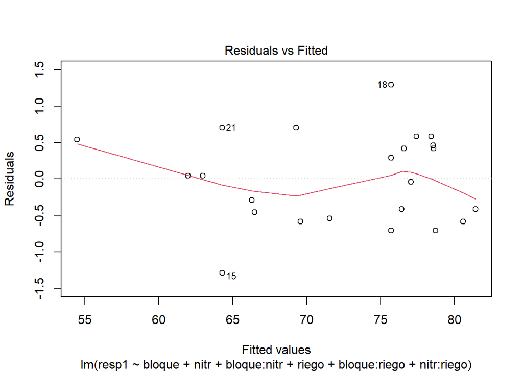

```r
# Modelo lineal completo para un arreglo en franjas
# Incluye los errores anidados correspondientes a cada factor
mod1 <- lm(resp1 ~ bloque + nitr + bloque:nitr + riego + bloque:riego + nitr:riego, data = franjas)

# 1. Homogeneidad de varianzas (Residuos vs. Predichos)
plot(mod1, 1)
```

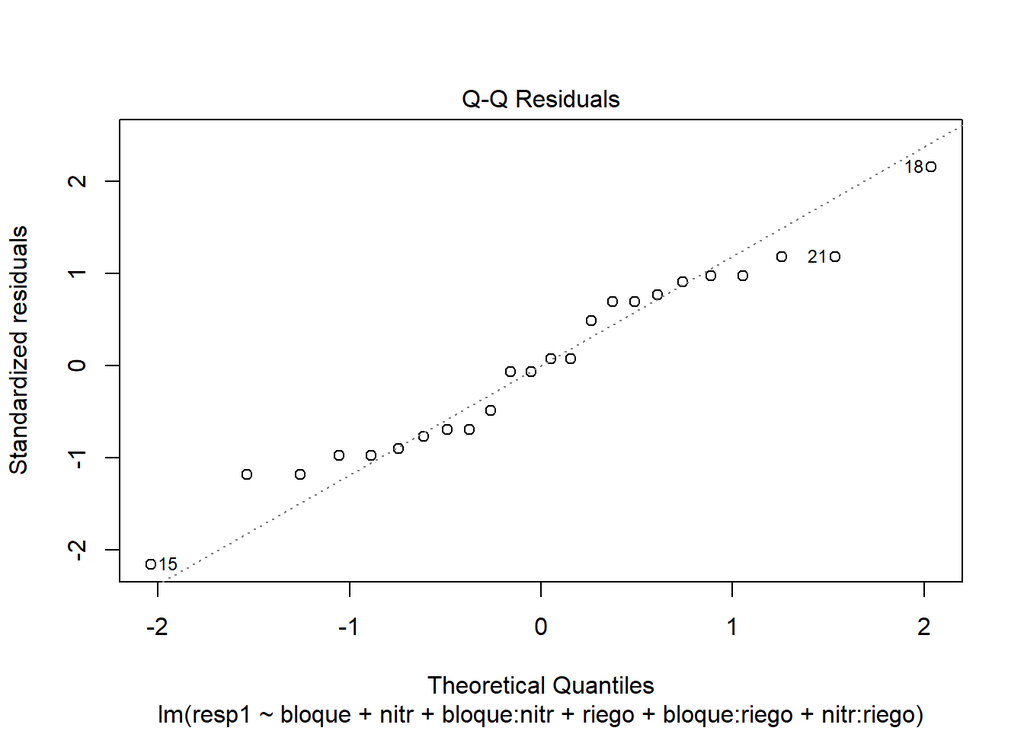

```r
# 2. Normalidad de los residuos (Q-Q Plot)
plot(mod1, 2)
```

```r
# 3. Prueba de normalidad de Shapiro-Wilk
shapiro.test(residuals(mod1))
```

```
##
##  Shapiro-Wilk normality test
##
## data:  residuals(mod1)
## W = 0.9671, p-value = 0.5961
```

- **Gráfico 1 (Residuals vs Fitted)**: Idealmente, los puntos deben distribuirse aleatoriamente alrededor de la línea horizontal en cero, sin patrones evidentes
- **Gráfico 2 (Normal Q-Q)**: Los puntos deben seguir de cerca la línea diagonal. Esto indica que los residuos siguen una distribución normal
- **Prueba de Shapiro-Wilk**: Si el p-valor es mayor a 0.05, no hay evidencia suficiente para rechazar la hipótesis nula de que los residuos son normales

# 6. Pruebas de comparación múltiple de medias (Post-Hoc)

Dado que el ANDEVA indica que hay diferencias significativas, pero no entre qué niveles, se emplea una prueba post-hoc de Tukey (HSD - Honest Significant Difference) para comparar las medias de los niveles de cada factor

**Importante**: Cada factor y la interacción deben ser probados con su cuadrado medio del error (`Ea`, `Eb`, `Ec`) y grados de libertad (`gl.a`, `gl.b`, `gl.c`) correspondientes, obtenidos del análisis con `agricolae`.

```r
# Factor A (Nitrógeno)
FactorA<-HSD.test(resp1,nitr,fran.anova$gl.a,fran.anova$Ea)
print(FactorA)
```

```
## $statistics
##    MSerror Df     Mean      CV      MSD
##   2.819444  6 72.45833 2.31736 2.576001
##
## $parameters
##    test name.t ntr StudentizedRange alpha
##   Tukey   nitr   3         4.339195  0.05
##
## $means
##      resp1      std r        se Min Max   Q25  Q50   Q75
## 0   68.250 7.995534 8 0.5936586  55  77 63.00 68.0 75.50
## 100 77.375 3.739270 8 0.5936586  69  81 76.75 78.5 79.25
## 50  71.750 6.562883 8 0.5936586  62  79 66.00 73.0 77.25
##
## $comparison
## NULL
##
## $groups
##      resp1 groups
## 100 77.375      a
## 50  71.750      b
## 0   68.250      c
##
## attr(,"class")
## [1] "group"
```

```r
# Factor B (Riego)
FactorB<-HSD.test(resp1,riego,fran.anova$gl.b,fran.anova$Eb)
print(FactorB)
```

```
## $statistics
##    MSerror Df     Mean       CV      MSD
##   10.93056  3 72.45833 4.562814 4.295429
##
## $parameters
##    test name.t ntr StudentizedRange alpha
##   Tukey  riego   2         4.500659  0.05
##
## $means
##         resp1      std  r        se Min Max   Q25  Q50  Q75
## Alto 77.33333 2.605356 12 0.9544001  71  81 76.75 77.5 79.0
## Bajo 67.58333 7.012435 12 0.9544001  55  79 63.00 66.0 71.5
##
## $comparison
## NULL
##
## $groups
##         resp1 groups
## Alto 77.33333      a
## Bajo 67.58333      b
##
## attr(,"class")
## [1] "group"
```

```r
# Interacción AB (Nitrógeno:Riego)
# Se crea una variable de interacción para la prueba
FactorAB<-HSD.test(resp1,riego:nitr,fran.anova$gl.c,fran.anova$Ec)
print(FactorAB)
```

```
## $statistics
##    MSerror Df     Mean       CV      MSD
##   1.430556  6 72.45833 1.650684 3.365919
##
## $parameters
##    test     name.t ntr StudentizedRange alpha
##   Tukey riego:nitr   6         5.628353  0.05
##
## $means
##          resp1      std r        se Min Max   Q25  Q50   Q75
## Alto:0   75.00 2.828427 4 0.5980292  71  77 74.00 76.0 77.00
## Alto:100 79.50 1.290994 4 0.5980292  78  81 78.75 79.5 80.25
## Alto:50  77.50 1.290994 4 0.5980292  76  79 76.75 77.5 78.25
## Bajo:0   61.50 4.434712 4 0.5980292  55  65 61.00 63.0 63.50
## Bajo:100 75.25 4.349329 4 0.5980292  69  79 74.25 76.5 77.50
## Bajo:50  66.00 3.265986 4 0.5980292  62  70 65.00 66.0 67.00
##
## $comparison
## NULL
##
## $groups
##          resp1 groups
## Alto:100 79.50      a
## Alto:50  77.50     ab
## Bajo:100 75.25      b
## Alto:0   75.00      b
## Bajo:50  66.00      c
## Bajo:0   61.50      d
##
## attr(,"class")
## [1] "group"
```

Los resultados muestran grupos de medias. Las medias que comparten una misma letra no son significativamente diferentes entre sí, según la prueba de Tukey (α = 0.05).

# 7. Alternativa de análisis con `AgroR`

```r
with(franjas, STRIPLOT(nitr, riego, bloque, resp1))
```

```
##
## -----------------------------------------------------------------
## Normality of errors
## -----------------------------------------------------------------
##                          Method Statistic  p.value
##  Shapiro-Wilk normality test(W) 0.9670957 0.596073
```

```
##
##
## -----------------------------------------------------------------
## Homogeneity of Variances
## -----------------------------------------------------------------
## Interaction
##                               Method Statistic   p.value
##  Bartlett test(Bartlett's K-squared)   1.96188 0.8543941
```

```
##
## -----------------------------------------------------------------
## Additional Information
## -----------------------------------------------------------------
##
## CV1 (%) =  2.32
## CV2 (%) =  4.56
## CV3 (%) =  1.65
## Mean =  72.4583
## Median =  76
##
##
## -----------------------------------------------------------------
## Analysis of Variance
## -----------------------------------------------------------------
##           Df    Sum Sq     Mean Sq   F value       Pr(>F)
## Block      3 123.458333  41.152778  3.340474 0.0973123560
## F1         2 339.083333 169.541667 60.133005 0.0001072987
## Error A    6  16.916667   2.819444
## F2         1 570.375000 570.375000 52.181703 0.0054703432
## Error B    3  32.791667  10.930556
## F1:F2      2  94.750000  47.375000 33.116505 0.0005731214
## Residuals  6   8.583333   1.430556
```